# Project Code

Seoulmates

Author

Christine Kim, Christine Lee, Zindeh Scere, Seoyeon Yoon

Published

December 4, 2023

Abstract

## 1 Data quality check / cleaning / preparation

Put code with comments. The comments should explain the code such that it can be easily understood. You may put text *(in a markdown cell)* before a large chunk of code to explain the overall purpose of the code, if it is not intuitive. **Put the name of the person / persons who contributed to each code chunk / set of code chunks.** An example is given below.

### 1.1 Listings Dataset - Cleaning/Preparation

*By Christine Kim*

```python
import pandas as pd
import numpy as np
import warnings
warnings.filterwarnings('ignore')

listings = pd.read_csv('listings.csv')
```

```python
# Selecting columns
listings_cleaned = listings.loc[:,['id', 'host_id', 'neighbourhood_cleansed', 'latitude', 'longitude', 'accommodates', 'amenities', 'price', 'host_response_time', 'host_response_rate', 'host_is_superhost', 'host_identity_verified', 'host_location', 'review_scores_rating', 'review_scores_accuracy', 'review_scores_cleanliness', 'review_scores_checkin', 'review_scores_communication', 'review_scores_location', 'review_scores_value']]

# Dropping missing values - rationale explained in report
listings_dropped = listings_cleaned.dropna()
listings_dropped.head()
missing_values_listings = listings_cleaned.loc[~listings_cleaned.id.isin(listings_dropped.id), :]

# Convert the string representation of lists into actual lists
listings_amenities = listings_dropped.copy()
listings_amenities['amenities'] = listings_amenities['amenities'].apply(lambda x: x.strip('[]').replace('"', '').split(', '))

# Get the unique list of amenities across all listings
all_amenities = set([amenity for sublist in listings_amenities['amenities'] for amenity in sublist])

# Create binary columns for each amenity
for amenity in all_amenities:
    listings_amenities[amenity] = listings_amenities['amenities'].apply(lambda x: 1 if amenity in x else 0)

listings_amenities = listings_amenities.drop('amenities', axis=1)
listings_noamen = listings_dropped.drop('amenities', axis=1)
```

```python
amenities_cat = listings_amenities.iloc[:,19:]
amenities_cat.columns = amenities_cat.columns.str.lower()
```

```python
# Categorizing amenities

# Listing keywords for each category
wifi_keywords = ['wifi']
bathroom_keywords = ['shampoo', 'body', 'conditioner', 'soap', 'shower gel', 'hair dryer']
kitchen_keywords = ['dining', 'fridge', 'oven', 'refrigerator', 'microwave', 'stove', 'blender', 'rice maker',
                    'bread maker', 'french press', 'nespresso', 'kitchen', 'dishwasher', 'coffee',
                    'baking', 'cooking', 'dishes', 'kettle', 'silverware', 'toaster', 'freezer', 'glasses']
leisure_keywords = ['chromecast', 'ping pong', 'piano', 'cable', 'video', 'ethernet', 'roku', 'hbo max', 'disney+',
                    'netflix', 'hulu', 'tv', 'games', 'game', 'books', 'sound', 'dvd', 'record player']
laundry_keywords = ['laundromat', 'washer', 'dryer', 'hangers', 'iron', 'clothing']
storage_keywords = ['closet', 'dresser', 'storage', 'wardrobe']
transportation_keywords = ['parking', 'garage', 'ev charger']
environment_keywords = ['mosquito net', 'heater', 'heated', 'heating', 'ac unit', 'ac - ', 'fan', 'fans', 'shades', 'fireplace', 'air conditioning']
safety_keywords = ['first aid','alarm', 'extinguisher','guard', 'safe', 'lock', 'keypad',
                   'security camera', 'outlet covers']
exercise_keywords = ['bikes', 'yoga mat', 'gym', 'exercise', 'stationary bike', 'treadmill', 'weights']
views_keywords = ['view', 'waterfront', 'lake access', 'beach access', 'resort access']
outdoor_keywords = ['barbecue', 'sun lounger', 'hammock', 'outdoor', 'patio', 'yard', 'fire pit', 'grill', 'beach']
luxury_keywords = ['bidet', 'hot tub', 'bathtub', 'pool', 'sauna', 'rooftop']
family_keywords =  ['crib', 'baby', 'children', 'changing table', 'high chair']
bedroom_keywords = ['blankets', 'pllows', 'linen']
pet_keywords = ['pet']
convenience_keywords = ['self check-in', 'luggage', 'elevator']
cleaning_keywords = ['cleaning products', 'trash']
service_cols = ['cleaning available', 'breakfast', 'host greets you', 'building staff']
smoking_keywords = ['smoking']
work_keywords = ['workspace']

def categorize_amenities(df, keywords, category_name):
    cols = [col for col in df.columns if any(keyword in col for keyword in keywords)]
    if cols:
        df[category_name] = df[cols].any(axis=1).astype(int)

        # Ensuring the new category column is not in the list of columns to drop
        cols_to_drop = [col for col in cols if col != category_name]

        df.drop(columns=cols_to_drop, inplace=True)


# Using defined function to categorize amenities
categorize_amenities(amenities_cat, wifi_keywords, 'wifi_amenities')
categorize_amenities(amenities_cat, bathroom_keywords, 'bathroom_amenities')
categorize_amenities(amenities_cat, kitchen_keywords, 'kitchen_amenities')
categorize_amenities(amenities_cat, leisure_keywords, 'leisure_amenities')
categorize_amenities(amenities_cat, laundry_keywords, 'laundry_amenities')
categorize_amenities(amenities_cat, storage_keywords, 'storage_amenities')
categorize_amenities(amenities_cat, transportation_keywords, 'transporation_amenities')
categorize_amenities(amenities_cat, environment_keywords, 'environment_amenities')
categorize_amenities(amenities_cat, safety_keywords, 'safety_amenities')
categorize_amenities(amenities_cat, exercise_keywords, 'exercise_amenities')
categorize_amenities(amenities_cat, views_keywords, 'views_amenities')
categorize_amenities(amenities_cat, outdoor_keywords, 'outdoor_amenities')
categorize_amenities(amenities_cat, luxury_keywords, 'luxury_amenities')
categorize_amenities(amenities_cat, family_keywords, 'family_amenities')
categorize_amenities(amenities_cat, bedroom_keywords, 'bedroom_amenities')
categorize_amenities(amenities_cat, pet_keywords, 'pet_amenities')
categorize_amenities(amenities_cat, convenience_keywords, 'convenience_amenities')
categorize_amenities(amenities_cat, cleaning_keywords, 'cleaning_amenities')
categorize_amenities(amenities_cat, service_cols, 'service_amenities')
categorize_amenities(amenities_cat, smoking_keywords, 'smoking_amenities')
categorize_amenities(amenities_cat, work_keywords, 'work_amenities')

# Adding amenity categories columns to listings dataset
listings_data = pd.concat([listings_noamen, amenities_cat], axis=1)
listings_data.head()
```

|  | id | host_id | neighbourhood_cleansed | latitude | longitude | accommodates | price | host_response_time | host_response_rate | host_is_superhost | ... | outdoor_amenities | luxury_amenities | family_amenities | bedroom_amenities | pet_amenities | convenience_amenities | cleaning_amenities | service_amenities | smoking_amenities | work_amenities |
| --- | --- | --- | --- | --- | --- | --- | --- | --- | --- | --- | --- | --- | --- | --- | --- | --- | --- | --- | --- | --- | --- |
| 0 | 2384.0 | 2613 | Hyde Park | 41.787900 | -87.587800 | 1 | $114.00 | within an hour | 100% | t | ... | 0 | 1 | 0 | 1 | 0 | 0 | 1 | 1 | 0 | 1 |
| 1 | 7126.0 | 17928 | West Town | 41.901660 | -87.680210 | 2 | $92.00 | within an hour | 100% | t | ... | 0 | 1 | 0 | 1 | 0 | 1 | 0 | 0 | 0 | 1 |
| 2 | 10945.0 | 33004 | Lincoln Park | 41.911960 | -87.639810 | 4 | $170.00 | within an hour | 93% | t | ... | 1 | 1 | 1 | 1 | 0 | 1 | 0 | 0 | 0 | 0 |
| 4 | 24833.0 | 101521 | Lincoln Park | 41.925961 | -87.656364 | 3 | $61.00 | within a few hours | 94% | t | ... | 1 | 1 | 1 | 1 | 1 | 1 | 1 | 0 | 0 | 1 |
| 5 | 25879.0 | 101521 | Lincoln Park | 41.924990 | -87.655730 | 6 | $95.00 | within a few hours | 94% | t | ... | 1 | 0 | 1 | 0 | 1 | 1 | 0 | 0 | 0 | 1 |

5 rows × 91 columns

```python
# Removing not meaningful amenities
irrelevant_amenities = ['essentials', 'hot water', 'long term stays allowed', 'private entrance', 'single level home', 'private living room']
listings_data_filtered = listings_data.drop(irrelevant_amenities, axis=1)

amenity_counts = amenities_cat.sum(axis=0)

notmeaningful_amenities = amenity_counts[amenity_counts <= 60].index.tolist()
listings_data_filtered = listings_data_filtered.drop(notmeaningful_amenities, axis=1)
listings_data_filtered.head()
```

|  | id | host_id | neighbourhood_cleansed | latitude | longitude | accommodates | price | host_response_time | host_response_rate | host_is_superhost | ... | outdoor_amenities | luxury_amenities | family_amenities | bedroom_amenities | pet_amenities | convenience_amenities | cleaning_amenities | service_amenities | smoking_amenities | work_amenities |
| --- | --- | --- | --- | --- | --- | --- | --- | --- | --- | --- | --- | --- | --- | --- | --- | --- | --- | --- | --- | --- | --- |
| 0 | 2384.0 | 2613 | Hyde Park | 41.787900 | -87.587800 | 1 | $114.00 | within an hour | 100% | t | ... | 0 | 1 | 0 | 1 | 0 | 0 | 1 | 1 | 0 | 1 |
| 1 | 7126.0 | 17928 | West Town | 41.901660 | -87.680210 | 2 | $92.00 | within an hour | 100% | t | ... | 0 | 1 | 0 | 1 | 0 | 1 | 0 | 0 | 0 | 1 |
| 2 | 10945.0 | 33004 | Lincoln Park | 41.911960 | -87.639810 | 4 | $170.00 | within an hour | 93% | t | ... | 1 | 1 | 1 | 1 | 0 | 1 | 0 | 0 | 0 | 0 |
| 4 | 24833.0 | 101521 | Lincoln Park | 41.925961 | -87.656364 | 3 | $61.00 | within a few hours | 94% | t | ... | 1 | 1 | 1 | 1 | 1 | 1 | 1 | 0 | 0 | 1 |
| 5 | 25879.0 | 101521 | Lincoln Park | 41.924990 | -87.655730 | 6 | $95.00 | within a few hours | 94% | t | ... | 1 | 0 | 1 | 0 | 1 | 1 | 0 | 0 | 0 | 1 |

5 rows × 40 columns

```python
listings_data_filtered['price'] = pd.to_numeric(listings_data_filtered['price'].str.replace('$', '').str.replace(',', ''), errors='coerce')
listings_data_filtered['host_response_rate'] = pd.to_numeric(listings_data_filtered['host_response_rate'].str.replace('%', '').str.replace(',', ''), errors='coerce')
```

Chose 60 as the threshold since the data has around ~6000 rows. Meaningful amenity if 1% of listed properties have it.

```python
listings_data_filtered.to_csv('listings_filtered.csv', index=False)
```

### 1.2 Calendar Dataset - Cleaning/Preparation

*By Christine Kim*

```python
# Quarterly Calendar data
calendar_december = pd.read_csv('calendar_December.csv')
calendar_march = pd.read_csv('calendar_March.csv')
calendar_june = pd.read_csv('calendar_June.csv')
calendar_september = pd.read_csv('calendar_September.csv')

# Convert to datetime
calendar_december['date'] = pd.to_datetime(calendar_december['date'])
calendar_march['date'] = pd.to_datetime(calendar_march['date'])
calendar_june['date'] = pd.to_datetime(calendar_june['date'])
calendar_september['date'] = pd.to_datetime(calendar_september['date'])

# Finding listings that included in all four quarters
common_listing_ids = set(calendar_december['listing_id']).intersection(calendar_march['listing_id'], calendar_june['listing_id'], calendar_september['listing_id'])
calendar_december = calendar_december[calendar_december['listing_id'].isin(common_listing_ids)]
calendar_march = calendar_march[calendar_march['listing_id'].isin(common_listing_ids)]
calendar_june = calendar_june[calendar_june['listing_id'].isin(common_listing_ids)]
calendar_september = calendar_september[calendar_september['listing_id'].isin(common_listing_ids)]

# Removing overlapping dates
calendar_december = calendar_december.loc[calendar_december['date']<'2023-03-19',:]
calendar_march = calendar_march.loc[calendar_march['date']<'2023-06-18',:]
calendar_june = calendar_june.loc[calendar_june['date']<'2023-09-12',:]
calendar_september = calendar_september.loc[calendar_september['date']<'2023-12-20',:]

# Concatenating quarterly data for yearly calendar data
calendar_year = pd.concat([calendar_december,calendar_march,calendar_june,calendar_september])
calendar_year.sort_values(by=['listing_id', 'date'], inplace=True)
calendar_year = calendar_year.drop(['minimum_nights', 'maximum_nights'], axis=1)
```

```python
calendar_year['price'] = pd.to_numeric(calendar_year['price'].str.replace('$', '').str.replace(',', ''), errors='coerce')
calendar_year['year'] = calendar_year['date'].dt.year
calendar_year['month'] = calendar_year['date'].dt.month
calendar_year = calendar_year.drop('available', axis=1)
calendar_year.head()
```

|  | listing_id | date | price | adjusted_price | year | month |
| --- | --- | --- | --- | --- | --- | --- |
| 0 | 2384 | 2022-12-20 | 80.0 | $80.00 | 2022 | 12 |
| 1 | 2384 | 2022-12-21 | 80.0 | $80.00 | 2022 | 12 |
| 2 | 2384 | 2022-12-22 | 80.0 | $80.00 | 2022 | 12 |
| 3 | 2384 | 2022-12-23 | 95.0 | $95.00 | 2022 | 12 |
| 4 | 2384 | 2022-12-24 | 95.0 | $95.00 | 2022 | 12 |

```python
calendar_year.to_csv('calendar_year.csv', index=False)
```

### 1.3 Data Quality Check: Listings Continuous Variables

```python
listings = pd.read_csv('listings_filtered.csv')
```

```python
continuous_var = listings.iloc[:, np.r_[2:5, 6, 8, 12:19]]
continuous_var.describe()
```

|  | latitude | longitude | price | host_response_rate | review_scores_rating | review_scores_accuracy | review_scores_cleanliness | review_scores_checkin | review_scores_communication | review_scores_location | review_scores_value |
| --- | --- | --- | --- | --- | --- | --- | --- | --- | --- | --- | --- |
| count | 5050.000000 | 5050.000000 | 5050.000000 | 5050.000000 | 5050.000000 | 5050.000000 | 5050.000000 | 5050.000000 | 5050.000000 | 5050.000000 | 5050.000000 |
| mean | 41.897704 | -87.666005 | 181.431881 | 98.177426 | 4.763786 | 4.807012 | 4.757745 | 4.849218 | 4.862881 | 4.766341 | 4.683382 |
| std | 0.062416 | 0.044503 | 206.919906 | 8.874949 | 0.373710 | 0.333659 | 0.379777 | 0.326767 | 0.329447 | 0.349515 | 0.405023 |
| min | 41.650640 | -87.847160 | 12.000000 | 0.000000 | 1.000000 | 1.000000 | 1.000000 | 1.000000 | 1.000000 | 1.000000 | 1.000000 |
| 25% | 41.867065 | -87.690289 | 86.000000 | 100.000000 | 4.700000 | 4.760000 | 4.690000 | 4.830000 | 4.860000 | 4.700000 | 4.620000 |
| 50% | 41.901555 | -87.662915 | 132.000000 | 100.000000 | 4.860000 | 4.900000 | 4.860000 | 4.940000 | 4.960000 | 4.880000 | 4.780000 |
| 75% | 41.940460 | -87.634164 | 213.000000 | 100.000000 | 4.970000 | 4.980000 | 4.980000 | 5.000000 | 5.000000 | 4.970000 | 4.890000 |
| max | 42.022200 | -87.536550 | 7585.000000 | 100.000000 | 5.000000 | 5.000000 | 5.000000 | 5.000000 | 5.000000 | 5.000000 | 5.000000 |

### 1.4 Data Quality Check: Listings Categorical Variables

```python
categorical_var = listings.iloc[:, np.r_[5, 7, 9:12, 19:40]]
```

```python
pd.set_option('display.max_colwidth', None)
categorical_distribution = pd.DataFrame()

for column in categorical_var.columns:
    num_missing = categorical_var[column].isnull().sum()
    num_unique = categorical_var[column].nunique()
    frequencies = categorical_var.groupby(column).size().reset_index(name='Frequency')

    top_frequencies = frequencies.sort_values(by='Frequency', ascending=False).head(5)

    categorical_distribution = categorical_distribution.append({
        'Variable': column,
        'Num_Missing': num_missing,
        'Num_Unique': num_unique,
        'Frequencies of levels': top_frequencies.set_index(column).to_dict()['Frequency']
    }, ignore_index=True)

categorical_distribution.set_index('Variable', inplace=True)

categorical_distribution
```

| Variable | Num_Missing | Num_Unique | Frequencies of levels |
| --- | --- | --- | --- |
| accommodates | 0 | 16 | {2: 1522, 4: 1067, 6: 750, 3: 310, 1: 308} |
| host_response_time | 0 | 4 | {'within an hour': 4410, 'within a few hours': 415, 'within a day': 186, 'a few days or more': 39} |
| host_is_superhost | 0 | 2 | {'t': 2640, 'f': 2410} |
| host_identity_verified | 0 | 2 | {'t': 4588, 'f': 462} |
| host_location | 0 | 168 | {'Chicago, IL': 4351, 'New York, NY': 197, 'United States': 55, 'Skokie, IL': 39, 'Springfield, IL': 33} |
| wifi_amenities | 0 | 2 | {1: 4998, 0: 52} |
| bathroom_amenities | 0 | 2 | {1: 4784, 0: 266} |
| kitchen_amenities | 0 | 2 | {1: 4998, 0: 52} |
| leisure_amenities | 0 | 2 | {1: 4766, 0: 284} |
| laundry_amenities | 0 | 2 | {1: 4990, 0: 60} |
| storage_amenities | 0 | 2 | {0: 4831, 1: 219} |
| transporation_amenities | 0 | 2 | {1: 4125, 0: 925} |
| environment_amenities | 0 | 2 | {1: 5040, 0: 10} |
| safety_amenities | 0 | 2 | {1: 5035, 0: 15} |
| exercise_amenities | 0 | 2 | {0: 4017, 1: 1033} |
| views_amenities | 0 | 2 | {0: 3883, 1: 1167} |
| outdoor_amenities | 0 | 2 | {1: 3093, 0: 1957} |
| luxury_amenities | 0 | 2 | {1: 2842, 0: 2208} |
| family_amenities | 0 | 2 | {0: 3381, 1: 1669} |
| bedroom_amenities | 0 | 2 | {1: 4178, 0: 872} |
| pet_amenities | 0 | 2 | {0: 3626, 1: 1424} |
| convenience_amenities | 0 | 2 | {1: 4405, 0: 645} |
| cleaning_amenities | 0 | 2 | {1: 2613, 0: 2437} |
| service_amenities | 0 | 2 | {0: 3897, 1: 1153} |
| smoking_amenities | 0 | 2 | {0: 4926, 1: 124} |
| work_amenities | 0 | 2 | {1: 3349, 0: 1701} |

### 1.5 Data Quality Check: Calendar dataset

```python
calendar_year = pd.read_csv('calendar_year.csv')
calendar_year.iloc[:, 2:].describe()
```

|  | price | year | month |
| --- | --- | --- | --- |
| count | 2.125760e+06 | 2.125760e+06 | 2.125760e+06 |
| mean | 2.147295e+02 | 2.022967e+03 | 6.526027e+00 |
| std | 1.294801e+03 | 1.783139e-01 | 3.447852e+00 |
| min | 1.000000e+01 | 2.022000e+03 | 1.000000e+00 |
| 25% | 8.700000e+01 | 2.023000e+03 | 4.000000e+00 |
| 50% | 1.370000e+02 | 2.023000e+03 | 7.000000e+00 |
| 75% | 2.150000e+02 | 2.023000e+03 | 1.000000e+01 |
| max | 9.999800e+04 | 2.023000e+03 | 1.200000e+01 |

## 2 Exploratory data analysis

Put code with comments. The comments should explain the code such that it can be easily understood. You may put text *(in a markdown cell)* before a large chunk of code to explain the overall purpose of the code, if it is not intuitive. **Put the name of the person / persons who contributed to each code chunk / set of code chunks.**

```python
import pandas as pd
import numpy as np
import matplotlib.pyplot as plt
import seaborn as sns
```

### 2.1 Analysis 1

*By Seoyeon Yoon*

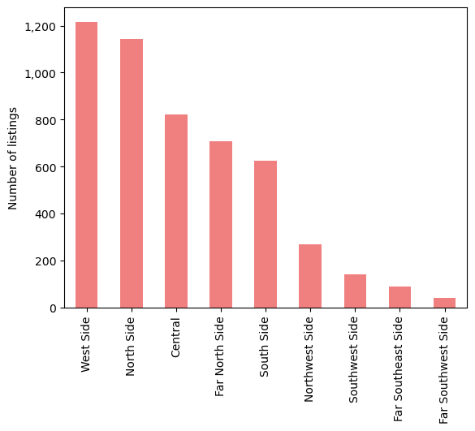

```python
## Visualization 1: Categorize Areas of Listing (Bar chart & Map plot)


#cleaning data and creating columns that are needed
listings_dropped = listings.dropna()
listings_dropped['price per person'] = listings_dropped['price']/listings_dropped['accommodates']

listings_dropped['area'] = np.select(
    [
        listings_dropped['neighbourhood_cleansed'].isin(['Near North Side', 'Loop', 'Near South Side']),
        listings_dropped['neighbourhood_cleansed'].isin(['Ohare', 'Norwood Park', 'Edison Park', 'Jefferson Park', 'Forest Glen', 'North Park', 'Albany Park', 'Lincoln Square', 'Rogers Park', 'West Ridge', 'Edgewater', 'Uptown']),
        listings_dropped['neighbourhood_cleansed'].isin(['Chatham', 'Avalon Park', 'Burnside', 'Roseland', 'West Pullman', 'Pullman', 'Riverdale', 'South Deering', 'Hegewisch', 'East Side', 'South Chicago', 'Calumet Heights']),
        listings_dropped['neighbourhood_cleansed'].isin(['Ashburn', 'Auburn Gresham', 'Washington Heights', 'Beverly', 'Morgan Park', 'Mount Greenwood']),
        listings_dropped['neighbourhood_cleansed'].isin(['North Center', 'Lake View', 'Lincoln Park', 'Logan Square', 'Avondale']),
        listings_dropped['neighbourhood_cleansed'].isin(['Dunning', 'Portage Park', 'Irving Park', 'Belmont Cragin', 'Hermosa', 'Montclare']),
        listings_dropped['neighbourhood_cleansed'].isin(['Bridgeport', 'Armour Square', 'Fuller Park', 'Douglas', 'Grand Boulevard', 'Oakland', 'Kenwood', 'Hyde Park', 'Woodlawn', 'South Shore', 'Greater Grand Crossing', 'Washington Park']),
        listings_dropped['neighbourhood_cleansed'].isin(['Mckinley Park', 'New City', 'Englewood', 'West Englewood', 'Chicago Lawn', 'West Lawn', 'Clearing', 'West Elsdon', 'Gage Park', 'Garfield Ridge', 'Archer Heights', 'Brighton Park']),
        listings_dropped['neighbourhood_cleansed'].isin(['Austin', 'Humboldt Park', 'West Garfield Park', 'East Garfield Park', 'West Town', 'Near West Side', 'North Lawndale', 'South Lawndale', 'Lower West Side'])
    ],
    [
        'Central',
        'Far North Side',
        'Far Southeast Side',
        'Far Southwest Side',
        'North Side',
        'Northwest Side',
        'South Side',
        'Southwest Side',
        'West Side'
    ],
    default='Other')

ax = listings_dropped['area'].value_counts()[:25].plot.bar(ylabel = 'Number of listings', color='lightcoral')
ax.yaxis.set_major_formatter('{x:,.0f}')
```

[figure not shown]

```python
import matplotlib.pyplot as plt

# Coordinates of listings
coordinates_listing = listings_dropped.iloc[:,3:5].to_numpy()

#Millennium Park Coordinates
mp_coord = np.array([41.8826, -87.6226])

def listing_viz():
    img = plt.imread("Chicago_Map.png")
    fig, ax = plt.subplots(figsize=(10, 100),dpi=80)
    fig.set_size_inches(20, 15)
    ax.imshow(img,extent=[-87.960529, -87.475380, 41.629367, 42.036972])
    plt.scatter(y = coordinates_listing[:,0], x = coordinates_listing[:,1], marker='o', color='lightcoral', zorder = 1)
    plt.scatter(y = mp_coord[0],  x = mp_coord[1], marker='*', color = 'blue', s= 500, zorder = 2)
    plt.xlim(-87.960529, -87.475380)
    plt.ylim(41.629367, 42.036972)
    plt.xlabel("Longitude")
    plt.ylabel("Latitude")
listing_viz()
```

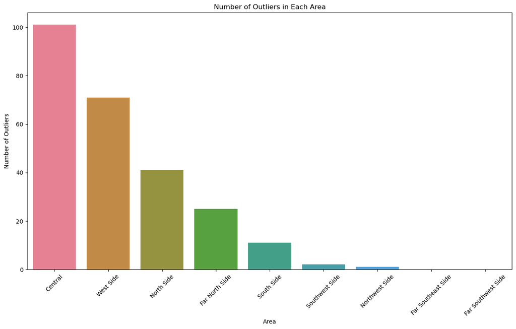

```python
## Visualization 2: Listings in City vs. Residential Areas Price (Outlier-adjusted)

# Calculate outliers using Tukey's method
def tukey_outliers(series):
    q1 = series.quantile(0.25)
    q3 = series.quantile(0.75)
    iqr = q3 - q1
    lower_bound = q1 - 1.5 * iqr
    upper_bound = q3 + 1.5 * iqr
    return (series < lower_bound) | (series > upper_bound)

# Identify outliers and count them for each area
listings_dropped['outliers'] = tukey_outliers(listings_dropped['price per person'])

outliers_by_area = listings_dropped.groupby('area')['outliers'].sum().reset_index()
outliers_by_area = outliers_by_area.sort_values(by='outliers', ascending=False)

# Create a bar plot for the number of outliers in each area
plt.figure(figsize=(15, 8))
sns.barplot(x='area', y='outliers', data=outliers_by_area, palette='husl')
plt.title('Number of Outliers in Each Area')
plt.xlabel('Area')
plt.ylabel('Number of Outliers')
plt.xticks(rotation=45)
plt.show()
```

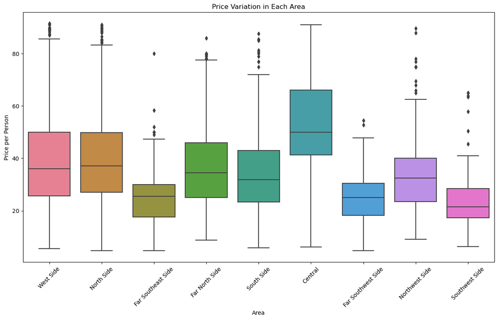

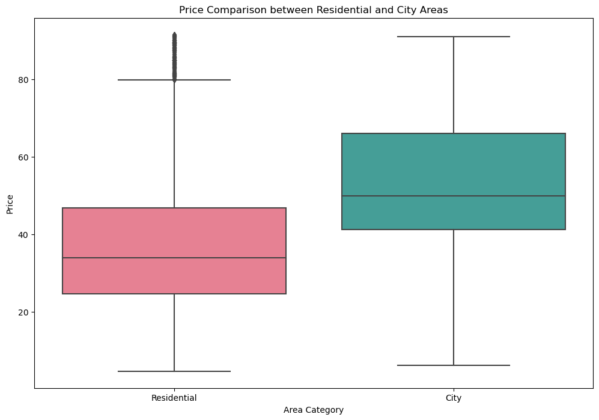

```
Percentage Difference in Price per Person for City compared to Overall Median: 42.11%
Percentage Difference in Price per Person for Residential compared to Overall Median: -8.55%
```

```python
wo_outliers = listings_dropped[listings_dropped['outliers'] == False]


# Create a box plot for price in each area
plt.figure(figsize=(15, 8))
sns.boxplot(x='area', y='price per person', data=wo_outliers, palette='husl')
plt.title('Price Variation in Each Area')
plt.xlabel('Area')
plt.ylabel('Price per Person')
plt.xticks(rotation=45)
plt.show()

# Create a new column 'area_category' to distinguish residential and city areas
listings_dropped['area_category'] = listings_dropped['area'].apply(lambda x: 'City' if x == 'Central' else 'Residential')
wo_outliers = listings_dropped[listings_dropped['outliers'] == False]

# Create a box plot for price comparison between residential and city areas
plt.figure(figsize=(12, 8))
sns.boxplot(x='area_category', y='price per person', data=wo_outliers, palette='husl')
plt.title('Price Comparison between Residential and City Areas')
plt.xlabel('Area Category')
plt.ylabel('Price')
plt.show()

# Calculate the median price per person for City and Residential areas
median_price_city = listings_dropped[listings_dropped['area_category'] == 'City']['price per person'].median()
median_price_residential = listings_dropped[listings_dropped['area_category'] == 'Residential']['price per person'].median()

# Calculate the median price for all listings
median_price_all = listings_dropped['price per person'].median()

# Calculate the percentage change in price per person for City and Residential areas compared to the median
percentage_change_city = ((median_price_city - median_price_all) / median_price_all) * 100
percentage_change_residential = ((median_price_residential - median_price_all) / median_price_all) * 100

print(f"Percentage Difference in Price per Person for City compared to Overall Median: {percentage_change_city:.2f}%")
print(f"Percentage Difference in Price per Person for Residential compared to Overall Median: {percentage_change_residential:.2f}%")
```

```
Pearson Correlation Coefficient for City: -0.2431514372110407
Pearson Correlation Coefficient for Residential: -0.13587967221351582
```

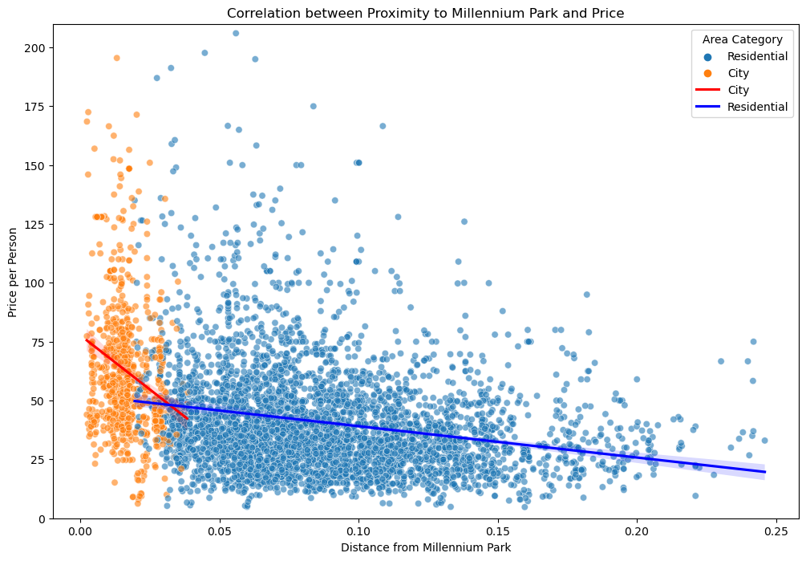

```python
## Visualization 3: Euclidean Distance

distance_from_mp = np.sqrt(np.sum((mp_coord-coordinates_listing)**2,axis=1))

distance_from_mp[distance_from_mp==0]=9999
closest_coord_index = np.argmin(distance_from_mp)
closest_coord_index


closest_coord = coordinates_listing[closest_coord_index,:]
closest_listing = listings_dropped.iloc[closest_coord_index, :]
closest_listing


farthest_coord_index = np.argmax(distance_from_mp)
farthest_coord = coordinates_listing[farthest_coord_index, :]
farthest_listing = listings_dropped.iloc[farthest_coord_index, :]

coordinates_listing[168,:]

listing_coord = np.array((closest_coord, farthest_coord))

# add new column of the distance between listings and the Millennium Park
distance_from_mp = np.sqrt(np.sum((mp_coord - np.array(listings_dropped[['latitude', 'longitude']])) ** 2, axis=1))
listings_dropped['distance_from_mp'] = distance_from_mp

#scatterplot
plt.figure(figsize=(12, 8))
sns.scatterplot(x='distance_from_mp', y='price per person', hue='area_category', data=listings_dropped, alpha=0.6)

#Regression line for City
sns.regplot(x='distance_from_mp', y='price per person', data=listings_dropped[listings_dropped['area_category'] == 'City'], scatter=False, color='red', label='City')

#Regression line for Residential
sns.regplot(x='distance_from_mp', y='price per person', data=listings_dropped[listings_dropped['area_category'] == 'Residential'], scatter=False, color='blue', label='Residential')

plt.title('Correlation between Proximity to Millennium Park and Price')
plt.xlabel('Distance from Millennium Park')
plt.ylabel('Price per Person')
plt.legend(title='Area Category', loc='upper right')
plt.ylim([0,210])

#Pearson coeff for City
correlation_city = listings_dropped[listings_dropped['area_category'] == 'City']['distance_from_mp'].corr(listings_dropped[listings_dropped['area_category'] == 'City']['price per person'])
print(f"Pearson Correlation Coefficient for City: {correlation_city}")

#Pearson coeff for Residential
correlation_residential = listings_dropped[listings_dropped['area_category'] == 'Residential']['distance_from_mp'].corr(listings_dropped[listings_dropped['area_category'] == 'Residential']['price per person'])
print(f"Pearson Correlation Coefficient for Residential: {correlation_residential}")

plt.show()
```

### 2.2 Analysis 2

*By Christine Kim*

```python
listings = pd.read_csv('listings_filtered.csv')
```

```python
# Removing price outliers
q1 = np.percentile(listings['price'],25)
q3 = np.percentile(listings['price'],75)
intQ_range = q3-q1

#Tukey's fences
Lower_fence = q1 - 1.5*intQ_range
Upper_fence = q3 + 1.5*intQ_range

Outlying_obs = listings[(listings.price<Lower_fence) | (listings.price>Upper_fence)]
Outlying_obs

listings_nooutlier = listings.drop(Outlying_obs.index)
listings_nooutlier.describe()
listings_nooutlier.columns
```

```
Index(['id', 'host_id', 'neighbourhood_cleansed', 'latitude', 'longitude',
       'accommodates', 'price', 'host_response_time', 'host_response_rate',
       'host_is_superhost', 'host_identity_verified', 'host_location',
       'review_scores_rating', 'review_scores_accuracy',
       'review_scores_cleanliness', 'review_scores_checkin',
       'review_scores_communication', 'review_scores_location',
       'review_scores_value', 'wifi_amenities', 'bathroom_amenities',
       'kitchen_amenities', 'leisure_amenities', 'laundry_amenities',
       'storage_amenities', 'transporation_amenities', 'environment_amenities',
       'safety_amenities', 'exercise_amenities', 'views_amenities',
       'outdoor_amenities', 'luxury_amenities', 'family_amenities',
       'bedroom_amenities', 'pet_amenities', 'convenience_amenities',
       'cleaning_amenities', 'service_amenities', 'smoking_amenities',
       'work_amenities'],
      dtype='object')
```

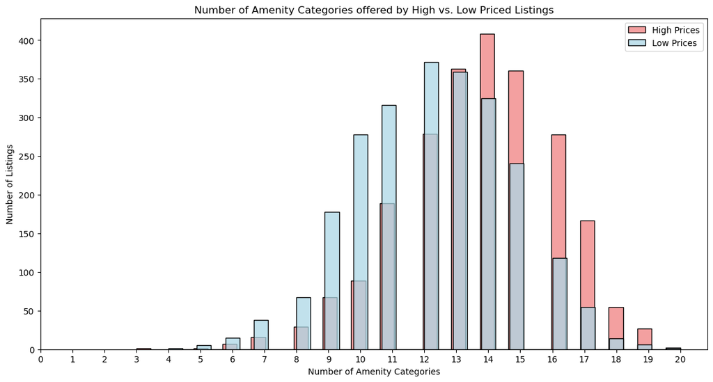

```python
## Visualization 1: Prevalence of each amenity category

median_price_threshold = listings_nooutlier['price'].quantile(0.5)

listings_nooutlier['amenity_count'] = listings_nooutlier.iloc[:, listings_nooutlier.columns.get_loc('wifi_amenities'):listings_nooutlier.columns.get_loc('work_amenities') + 1].sum(axis=1)

# Bin into high and low prices
high_prices = listings_nooutlier[listings_nooutlier['price'] > median_price_threshold]['amenity_count']
low_prices = listings_nooutlier[listings_nooutlier['price'] <= median_price_threshold]['amenity_count']

plt.figure(figsize=(14, 7))
ax1 = sns.histplot(high_prices, color="lightcoral", label='High Prices', kde=False)
ax2 = sns.histplot(low_prices, color="lightblue", label='Low Prices', kde=False)
plt.xlabel('Number of Amenity Categories')
plt.ylabel('Number of Listings')
ax1.set_xticks(np.arange(0,21,1))
plt.title('Number of Amenity Categories offered by High vs. Low Priced Listings')
plt.legend()
plt.show()
```

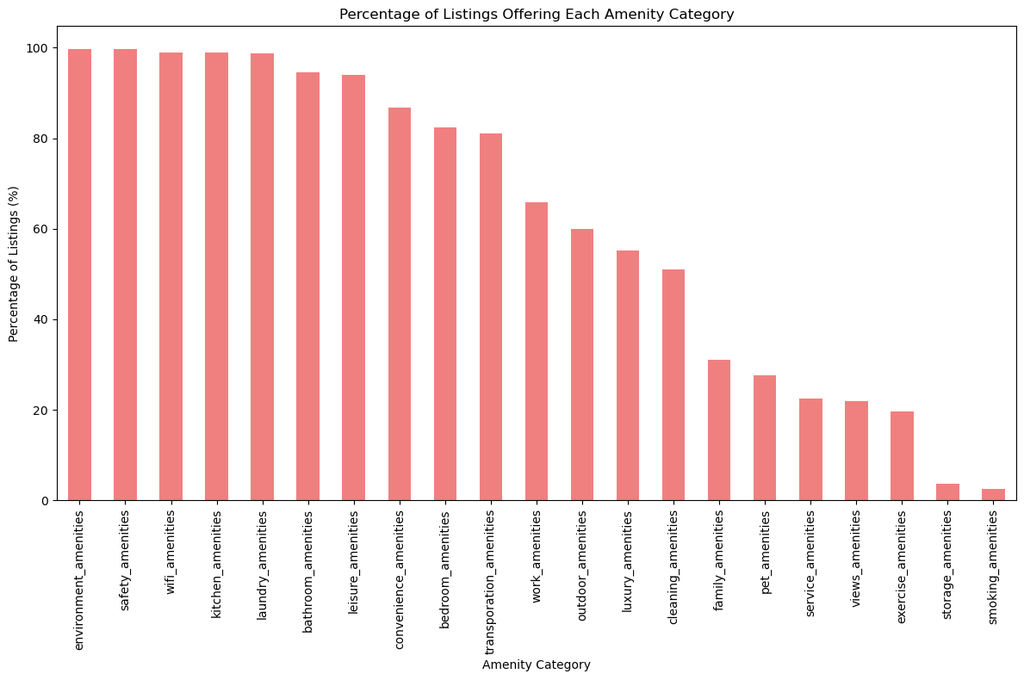

```python
## Visualization 2: Prevalence of each amenity category

amenities_count = listings_nooutlier.iloc[:, listings_nooutlier.columns.get_loc('wifi_amenities'):listings_nooutlier.columns.get_loc('work_amenities') + 1].sum().sort_values(ascending=False)

amenity_categories = list(amenities_count.index)

percentages = listings_nooutlier[amenity_categories].mean() * 100
sorted_percentages = percentages.sort_values(ascending=False)

plt.figure(figsize=(12, 8))
sorted_percentages.plot(kind='bar', color='lightcoral')
plt.title('Percentage of Listings Offering Each Amenity Category')
plt.xlabel('Amenity Category')
plt.ylabel('Percentage of Listings (%)')
plt.xticks(rotation=90)
plt.tight_layout()
plt.show()
```

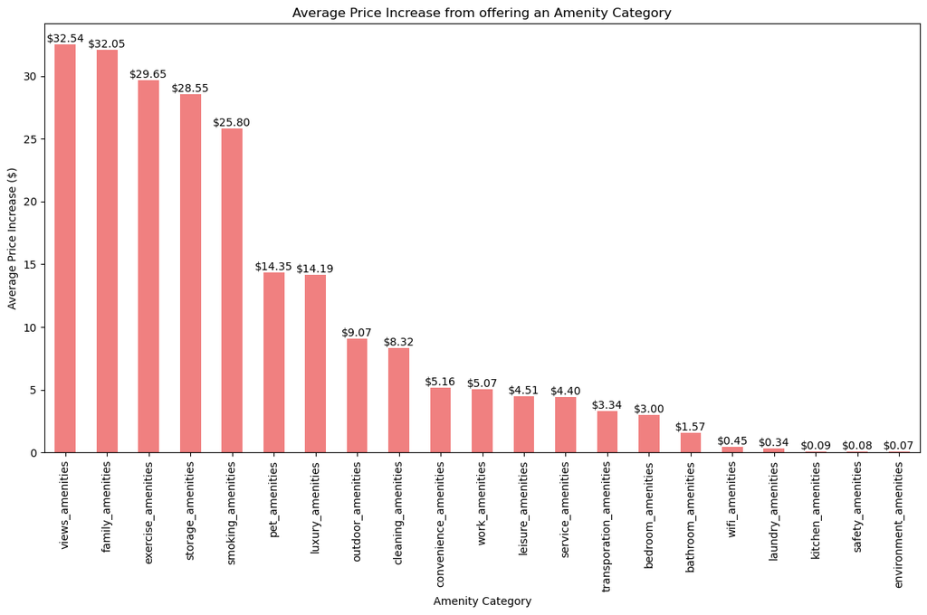

```python
## Visualization 3: Prevalence of each amenity category

overall_average_price = listings_nooutlier['price'].mean()

# Dictionary to store the price differential for each amenity
price_differential = {}

# Iterate over each amenity category to calculate the average price and price differential
for amenity_category in amenity_categories:
    has_amenity = listings_nooutlier[listings_nooutlier[amenity_category] == 1]['price'].mean()
    price_differential[amenity_category] = has_amenity - overall_average_price

sorted_differential = pd.Series(price_differential).sort_values(ascending=False)

fig, ax = plt.subplots(figsize=(12, 8))
sorted_differential.plot(kind='bar', color='lightcoral', ax=ax)
ax.set_title('Average Price Increase from offering an Amenity Category')
ax.set_xlabel('Amenity Category')
ax.set_ylabel('Average Price Increase ($)')
ax.axhline(0, color='black', linewidth=0.8)

# Annotate bars with the value of the price differential
for i, v in enumerate(sorted_differential):
    ax.text(i, v if v > 0 else 0, f"${v:.2f}", color='black', ha='center', va='bottom')

plt.xticks(rotation=90)
plt.tight_layout()
plt.show()
```

### 2.3 Analysis 3

*By Zindeh Scere*

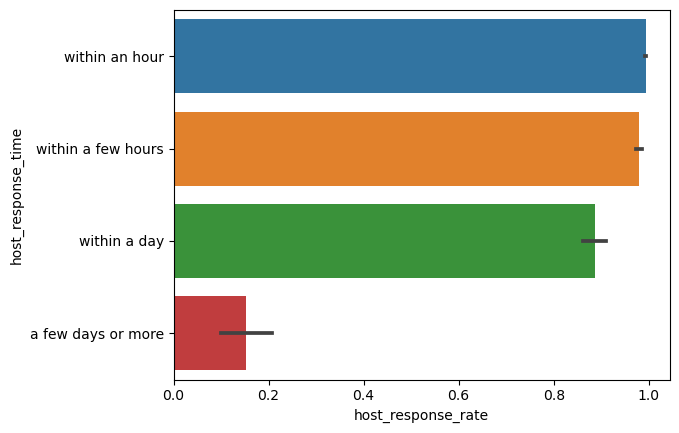

```python
listings.host_response_rate = listings.host_response_rate.astype(float)/100

sns.barplot(data = listings, x = 'host_response_rate', y = 'host_response_time')
```

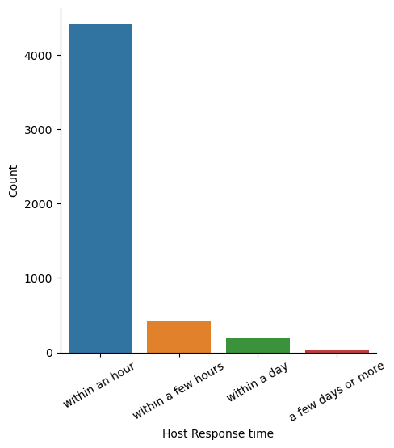

```python
a = sns.catplot(data = listings, x = 'host_response_time', kind = 'count',)
a.set_axis_labels("Host Response time", "Count")
a.set_xticklabels(rotation=30)
```

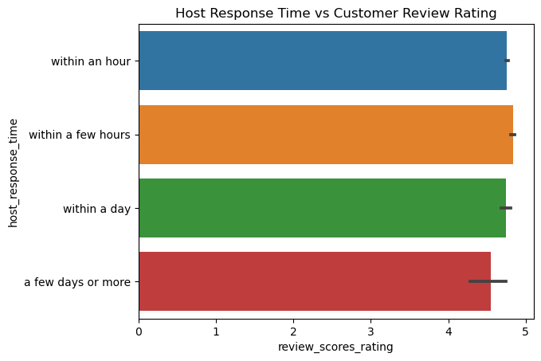

```python
sns.barplot(data = listings, x = 'review_scores_rating', y = 'host_response_time')
plt.title('Host Response Time vs Customer Review Rating')
```

```python
dummy = pd.get_dummies(listings.host_response_time)
print('Correlation between Host Response Time and Rate:\n', dummy.corrwith(listings.host_response_rate), '\n', '\n'
      'Correlation between Host Response Time and Overall Rating:\n',
      dummy.corrwith(listings.review_scores_rating))
```

```
Correlation between Host Response Time and Rate:
 a few days or more   -0.825115
within a day         -0.209463
within a few hours   -0.006145
within an hour        0.340784
dtype: float64

Correlation between Host Response Time and Overall Rating:
 a few days or more   -0.050110
within a day         -0.007637
within a few hours    0.058116
within an hour       -0.030468
dtype: float64
```

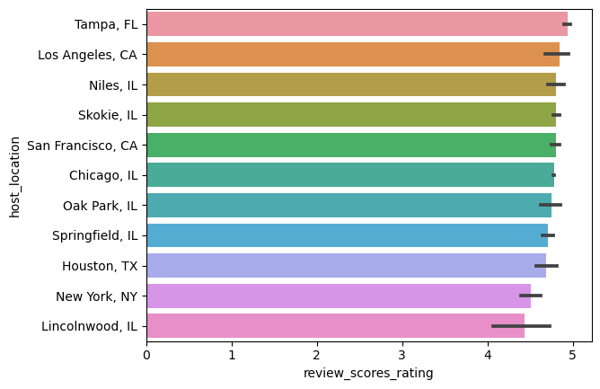

```python
top_5 = listings.host_location.value_counts()>=10
top_5_loc = listings.loc[listings.host_location.isin(top_5[top_5].index.to_list()),:]

list_loc = top_5_loc[['host_location', 'review_scores_rating']].groupby('host_location').mean()\
.drop(['United States', 'Illinois, United States']).sort_values(by = 'review_scores_rating',
                                                                ascending= False).index.to_list()
sns.barplot(x = 'review_scores_rating', y = 'host_location', data=listings, order=list_loc)
```

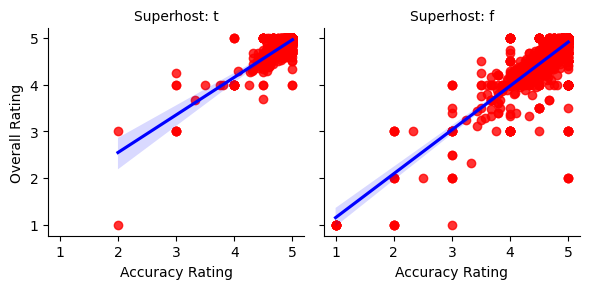

```python
a = sns.FacetGrid(listings, col = 'host_is_superhost', col_wrap = 2)
a.map_dataframe(sns.regplot, x = 'review_scores_accuracy', y = 'review_scores_rating', scatter_kws={"color": "red"}, line_kws={"color": "blue"})
a.set_titles(col_template= 'Superhost: {col_name}')

a.set_xlabels('Accuracy Rating')
a.set_ylabels('Overall Rating')
```

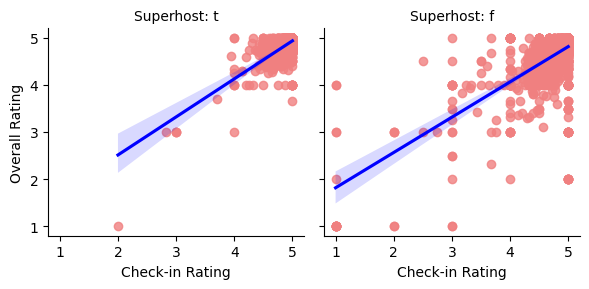

```python
c = sns.FacetGrid(listings, col = 'host_is_superhost', col_wrap = 2)
c.map_dataframe(sns.regplot, x = 'review_scores_checkin', y = 'review_scores_rating', scatter_kws={"color": "lightcoral"}, line_kws={"color": "blue"})
c.set_titles(col_template= 'Superhost: {col_name}')

c.set_xlabels('Check-in Rating')
c.set_ylabels('Overall Rating')
```

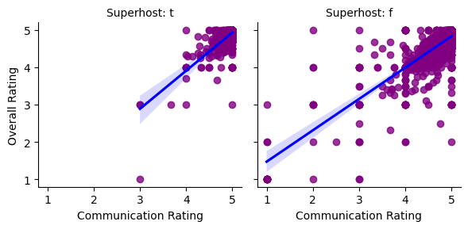

```python
b = sns.FacetGrid(listings, col = 'host_is_superhost', col_wrap = 2)
b.map_dataframe(sns.regplot, x = 'review_scores_communication', y = 'review_scores_rating', scatter_kws={"color": "purple"}, line_kws={"color": "blue"})
b.set_titles(col_template= 'Superhost: {col_name}')
b.set_xlabels('Communication Rating')
b.set_ylabels('Overall Rating')
```

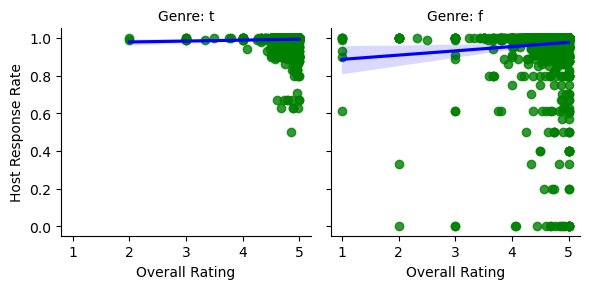

```python
f = sns.FacetGrid(listings, col = 'host_is_superhost', col_wrap = 2)
f.map_dataframe(sns.regplot, x = 'review_scores_accuracy', y = 'host_response_rate', scatter_kws={"color": "green"}, line_kws={"color": "blue"})
f.set_titles(col_template= 'Genre: {col_name}')

f.set_ylabels('Host Response Rate')
f.set_xlabels('Overall Rating')
```

```python
vals = listings.loc[:,['host_identity_verified', 'host_response_rate', 'host_is_superhost', 'review_scores_rating', 'review_scores_accuracy',
       'review_scores_cleanliness', 'review_scores_checkin',
       'review_scores_communication', 'review_scores_location',
       'review_scores_value']]
```

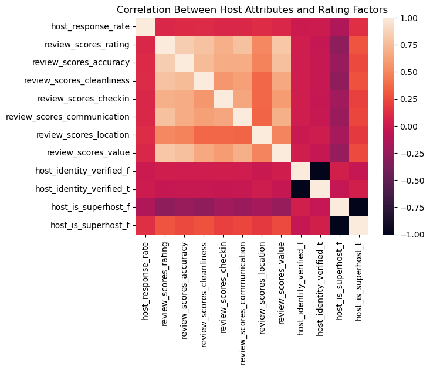

```python
sns.heatmap(pd.get_dummies(vals).corr())
plt.title('Correlation Between Host Attributes and Rating Factors')
```

### 2.4 Analysis 4

*By Christine Lee*

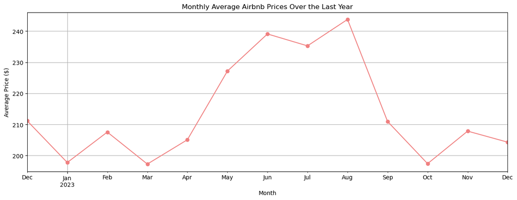

```python
## Visualization 1: Monthly Average Airbnb Prices Over the Last Year

# Filter data to only include the last year
one_year_ago = pd.Timestamp('2023-09-12') - pd.DateOffset(years=1)
last_year_data = calendar_year[calendar_year['date'] >= one_year_ago]

# Group by month and calculate the average price for each month
last_year_data['month'] = last_year_data['date'].dt.to_period('M')
monthly_prices = last_year_data.groupby('month')['price'].mean()

# Plotting the line graph
plt.figure(figsize=(15, 5))
monthly_prices.plot(kind='line', color='lightcoral', marker='o', linestyle='-')
plt.title('Monthly Average Airbnb Prices Over the Last Year')
plt.xlabel('Month')
plt.ylabel('Average Price ($)')
plt.grid(True)

plt.show()
```

[figure not shown]

```python
## Visualization 2: Average Airbnb Prices during Seasonal Holidays

# Convert 'date' column to datetime type
last_year_data['date'] = pd.to_datetime(last_year_data['date'])

# Extract month and day to identify holidays
last_year_data['month_day'] = last_year_data['date'].dt.strftime('%m-%d')

# Define holiday periods
holidays = {
    'Easter': ['04-04', '04-05', '04-06'],
    'Summer Vacation': ['06-01', '08-31'],
    'Thanksgiving': ['11-25', '11-26', '11-27'],
    'Christmas': ['12-24', '12-25', '12-26']

}

# Create a new column 'holiday' to label each day
last_year_data['holiday'] = 'None'
for holiday, dates in holidays.items():
    last_year_data.loc[last_year_data['month_day'].isin(dates), 'holiday'] = holiday

# Group by holiday and calculate the mean price
holiday_prices = last_year_data.groupby('holiday')['price'].mean().reset_index()

# Sort holidays by their mean prices
holiday_prices = holiday_prices.sort_values(by='price', ascending=False)

colors = ['lightcoral', 'lightblue', 'lightgreen', 'lightpink']

# Plot the data
plt.figure(figsize=(10, 6))
plt.bar(holiday_prices['holiday'], holiday_prices['price'], color=colors) #colors needs to be defined
plt.title('Average Airbnb Prices during Seasonal Holidays')
plt.xlabel('Holiday')
plt.ylabel('Mean Price ($)')
plt.xticks(rotation=45, ha='right')


# Set y-axis range to highlight variability
plt.ylim(min(holiday_prices['price']) - 10, max(holiday_prices['price']) + 10)

plt.show()
```

[figure not shown]

```python
## Visualization 3: Average Airbnb Prices during Special Events in Chicago

# Define special events and their date ranges
events = {
    'Chicago Marathon': ['2023-10-08'],
    'Chicago Blues Festival': ['2023-06-08', '2023-06-09', '2023-06-10', '2023-06-11'],
    'Lollapalooza': ['2023-08-03', '2023-08-04', '2023-08-05', '2023-08-06'],
    'Chicago Jazz Festival': ['2023-08-31', '2023-09-01', '2023-09-02', '2023-09-03'],
    'Chicago Air and Water Show': ['2023-08-19', '2023-08-20'],
    'NASCAR Chicago Street Race': ['2023-7-1', '2023-7-2']
}

# Create a new column 'event' to label each day
last_year_data['event'] = 'None'
for event, dates in events.items():
    last_year_data.loc[last_year_data['date'].isin(dates), 'event'] = event

# Group by event and calculate the mean price
event_prices = last_year_data.groupby('event')['price'].mean().reset_index()

# Sort events by their mean prices
event_prices = event_prices.sort_values(by='price', ascending=False)

# Define different colors for each holiday
colors = ['lightcoral', 'lightblue', 'lightgreen', 'lightpink']

# Plot the data
plt.figure(figsize=(12, 6))
bars = plt.bar(event_prices['event'], event_prices['price'], color=colors)
plt.title('Average Airbnb Prices during Special Events in Chicago')
plt.xlabel('Special Event')
plt.ylabel('Mean Price ($)')
plt.xticks(rotation=45, ha='right')

# Set y-axis range to highlight variability
plt.ylim(min(event_prices['price']) - 10, max(event_prices['price']) + 10)

plt.show()
```

[output not shown]